# Bayesian Analysis of Arrest Data from Pickens County, Ga

## Abstract

*I performed a Bayesian data analysis on web-scraped arrest ("just busted") data from Pickens County, Ga. I begin with an exploratory data analysis of the data and several key variables. Then, I fit a linear regression model to estimate the effects of several variables on bond amounts charged. Lastly, I fit a Poisson linear regression model to estimate the effects of different types of seasonality on the number of people arrested per day.*

## Background and Introduction

For this Bayesian data analysis, I am analyzing arrest (or “just busted”) data from my hometown, Pickens County, Ga. I scraped the data from this [website⁽¹⁾](https://bustednewspaper.com/mugshots/georgia/pickens-county/), and it includes fields such as the individual’s name, age, sex, race, etc. (all of which will be explored in a later section).

In this analysis, I seek to answer the following two questions using Bayesian methods:

1. Is it possible to predict or explain the bond amounts charged given a set of input factors? In this section of the analysis, a linear regression model will be fit to the data with the bond amount as the response. I will investigate which variables are significant (based on their HPD) and whether or not the model offers significant predictive or explanatory power.
2. Is it possible to predict the number of arrests per day by knowing the day of the week or the month of the year? In this section, I will fit a Poisson linear regression model to the daily number of arrests in order to see how much variation can be explained by these factors.

## Data Description and EDA

At the time of writing, there were 3,383 records available for Pickens County, Ga, with the earliest record dating back to October 2018.

The data used for this analysis has been pre-processed/cleaned extensively. Pre-processing included aggregating bond amounts, putting all charges into a text string, using k-means to cluster the charges into similar buckets, computing charge per bond required, etc. Reach out to me if you would be interested in see the Python code for these pre-processing steps.

Here is a preview of the data set used for estimating bond charges:

### Data Preview

```python
import pandas as pd
import numpy as np
import seaborn as sns
import matplotlib.pyplot as plt

import pymc3 as pm
import arviz as az
import scipy

import warnings
warnings.filterwarnings('ignore')

busted = pd.read_csv('code/src/busted.csv')
busted['race'] = busted['race'].astype('category')
busted['race'].cat.rename_categories({'A': 'Asian', 'B': 'African-American', 'L': 'Latino/Hispanic', 'W': 'White'}, inplace = True)
busted['sex'] = busted['sex'].astype('category')
busted['sex'].cat.rename_categories({'M': 'Male', 'F': 'Female'}, inplace = True)
busted['charge_cluster'] = busted['charge_cluster'].astype('category')

busted.head(5)
```

|  | id | name | datetime | url | age | height | weight | hair | eye | race | sex | address | arrested_by | bond_sum | charges | charge_count | charge_per_bond | charge_cluster |
| --- | --- | --- | --- | --- | --- | --- | --- | --- | --- | --- | --- | --- | --- | --- | --- | --- | --- | --- |
| 0 | 3379 | Ashley Champion | 2021-04-21 01:29:00 | https://bustednewspaper.com/georgia/champion-a... | 29 | 69.0 | 200.0 | BRO | Green | White | Female | Ellijay , GA 30536 | PICKENS CO. SHERIFFS OFFICE | 1500.0 | drive w/ license susp/revoked no tag light ... | 2 | 750.00 | 1 |
| 1 | 3381 | Dwayne Edward Weaver | 2021-04-20 17:53:00 | https://bustednewspaper.com/georgia/weaver-dwa... | 56 | 67.0 | 150.0 | GRY | BRO | White | Male | JASPER, GA 30413 | PICKENS CO. SHERIFFS OFFICE | 1200.0 | drive w/ license susp/revoked | 1 | 1200.00 | 36 |
| 2 | 3383 | Austin Cole Carter | 2021-04-19 23:59:00 | https://bustednewspaper.com/georgia/carter-aus... | 31 | 69.0 | 183.0 | BLK | GRN | White | Male | Ellijay, GA 30540 | PICKENS CO. SHERIFFS OFFICE | 1500.0 | stalking | 1 | 1500.00 | 22 |
| 3 | 3375 | Christy Nicole Hunt | 2021-04-19 23:09:00 | https://bustednewspaper.com/georgia/hunt-chris... | 40 | 64.0 | 220.0 | RED | Blue | White | Female | Cleveland, TN 37323 | PICKENS CO. SHERIFFS OFFICE | 1800.0 | dui - alcohol failure to maintain lane | 2 | 900.00 | 18 |
| 4 | 3373 | Frank Glenn Faber | 2021-04-18 08:18:00 | https://bustednewspaper.com/georgia/faber-fran... | 45 | 69.0 | 145.0 | BRO | BRO | White | Male | Jasper, GA 30143 | JASPER POLICE DEPARTMENT | 1685.0 | speeding reckless driving following too close... | 4 | 421.25 | 46 |

Most of the fields are self-explanatory, but I would like to point out that the charge_cluster field is just the application of a k-means clustering algorithm to bucket similar charges into 50 different categories. This variable is used as a controlling variable in the linear regression model. Also, I am normalizing the total bond amounts charged by dividing that figure by the number of charges assessed (this is the charge_per_bond column).

I'll be using a subset of the variables available for the linear regression, namely: charge_per_bond as the dependent variable, and age, race, sex, and charge_cluster as the independent variables.

I'll show charts of a selection of these variables below.

### Histogram - Bond Amount per Charge

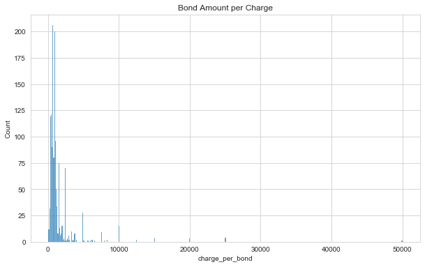

```python
sns.set_style("whitegrid")
busted_subset = busted[['charge_per_bond','age','sex','race','charge_cluster']]

# Basic histogram
plt.figure(figsize=(10,6))
sns.histplot(data = busted_subset, x = "charge_per_bond", palette="deep")
plt.title('Bond Amount per Charge')
plt.show()
```

### Histogram - Log(Bond Amount per Charge)

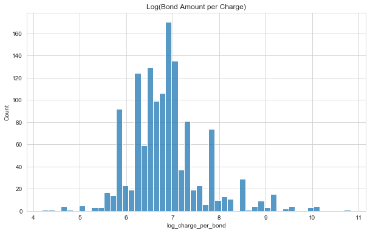

```python
busted_subset['log_charge_per_bond'] = np.log(busted_subset['charge_per_bond'])
# Basic histogram
plt.figure(figsize=(10,6))
sns.histplot(data = busted_subset, x = "log_charge_per_bond", palette="deep")
plt.title('Log(Bond Amount per Charge)')
plt.show()
```

Since the distribution of the bond amounts is very right skewed, I will be using the log transformation of the variable in further analysis. The log transformation, as can be seen directly above, appears to be approximately normal, although with heavy tails.

Next, let's look at the distribution of the ages of individuals within the dataset:

### Histogram - Age

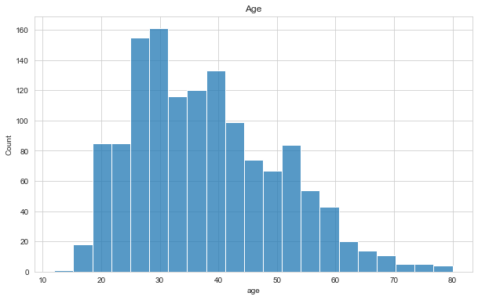

```python
# Basic histogram
plt.figure(figsize=(10,6))
sns.histplot(data = busted_subset, x = "age", palette="deep")
plt.title('Age')
plt.show()
```

As can be seen above, the age of arrests in this dataset is not a normal distribution and is skewed by the older ages. Most individuals arrested appear to be within the ages of 20 and 40.

### Boxplot - Log(Bond Amount per Charge) vs. Sex

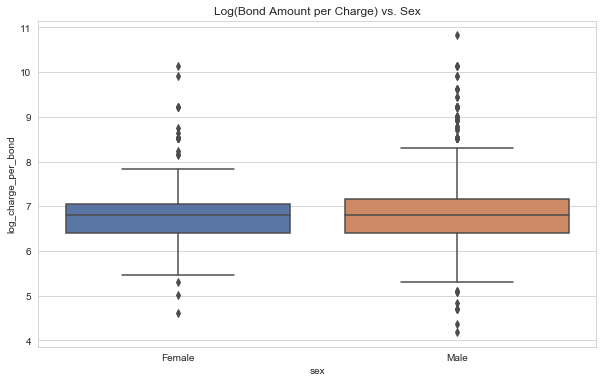

```python
plt.figure(figsize=(10,6))
sns.boxplot(x = "sex", y = "log_charge_per_bond", data = busted_subset, palette="deep")
plt.title('Log(Bond Amount per Charge) vs. Sex')
plt.show()
```

While males appear to have a higher amount of variation in their bond amounts, there doesn't appear to be any discernable difference in the mean. However, it should be mentioned that males outnumber females in this dataset by about 3:1, which may result in a sampling bias in fitting the model and could affect coefficient estimates.

### Boxplot - Log(Bond Amount per Charge) vs. Race

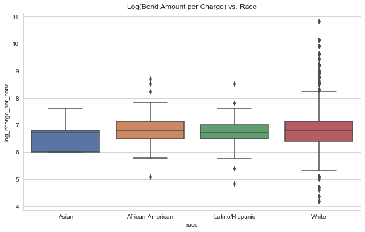

```python
plt.figure(figsize=(10,6))
sns.boxplot(x = "race", y = "log_charge_per_bond", data = busted_subset, palette="deep")
plt.title('Log(Bond Amount per Charge) vs. Race')
plt.show()
```

Visually, it's hard to tell if there is any difference in the means of the bond charges for the four racial groups, however there are some differences in variance. I should also point out here that whites make up the overwhelming majority of the arrests in this dataset, so there is not necessarily a representative sample from the arrests of other races, which again could potentially affect coefficient estimates.

### Boxplot - Log(Bond Amount per Charge) vs. Charge Cluster

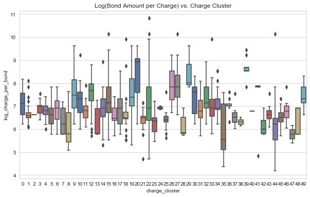

```python
plt.figure(figsize=(10,6))
sns.boxplot(x = "charge_cluster", y = "log_charge_per_bond", data = busted_subset, palette="deep")
plt.title('Log(Bond Amount per Charge) vs. Charge Cluster')
plt.show()
```

There does seem to be a significant amount of variation in many of the categories, which makes sense because the bond amount charged should correspond most directly to the charges made. Bond amounts for DUIs would be very different from those that involve forgery, for example. That being said, there remains a very wide spread in the distribution of bond amounts for most of these charge groups. This could be an indication that this variation is the result of one of the other variables in the dataset, a variable outside of the dataset, or misclassification in the clustering of the charges.

### Time Series Data

Let's take a quick look at the time series data that will be used in the second part of this analysis. The y-axis will show the count of arrests. I will show this plot at three different levels: daily, weekly, and monthly.

#### Daily Time Series

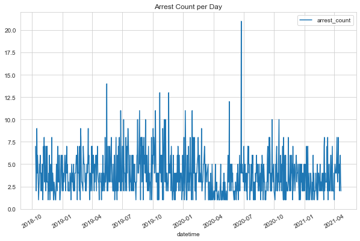

```python
# read in data
time_series = pd.read_csv('code/src/busted_timeseries.csv')
time_series = time_series[['datetime','count']].set_index(time_series['datetime'])
time_series = time_series[['count']]
time_series.rename(columns = {'count': 'arrest_count'}, inplace = True)
time_series.index = pd.to_datetime(time_series.index)

# create the time series plot
plt.figure(figsize=(10,6))
sns.lineplot(data = time_series)
plt.title('Arrest Count per Day')
plt.xticks(rotation=30)
plt.show()
```

#### Weekly Time Series

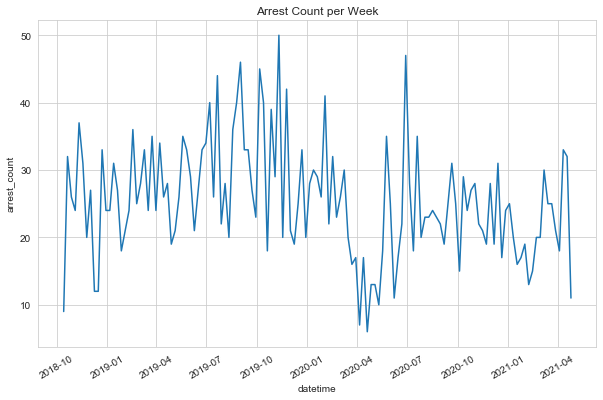

```python
# resample to weekly series
weekly_time_series = time_series.resample('W').arrest_count.sum()

# plot the series
plt.figure(figsize=(10,6))
sns.lineplot(data = weekly_time_series)
plt.title('Arrest Count per Week')
plt.xticks(rotation=30)
plt.show()
```

#### Monthly Time Series

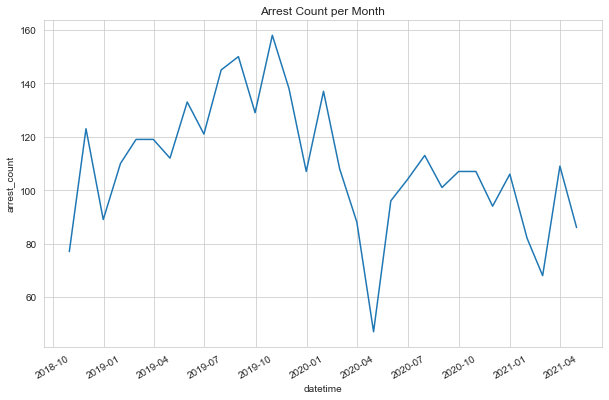

```python
# resample to monthly series
monthly_time_series = time_series.resample('M').arrest_count.sum()

# plot the series
plt.figure(figsize=(10,6))
sns.lineplot(data = monthly_time_series)
plt.title('Arrest Count per Month')
plt.xticks(rotation=30)
plt.show()
```

## Bayesian Linear Regression for Bond Estimation

### Model Description and Estimation

Below, I will construct the linear model for estimating the per charge bond amounts.

This model will be of the form:

$\hat{logbondcharge_i} = \beta_{intercept} + \beta_{age}*age + \beta_{gender}*gender + \beta_{race}*race + \beta_{chargecluster}*chargecluster$

This is a simplified equation. Note that several of the variables above are categorical, and that pymc3 will one-hot encode these variables to estimate a coefficient for each category of the variable.

Next, I will train the model.

```python
with pm.Model() as model:
    # specify glm and pass in data. The resulting linear model, its likelihood and
    # and all its parameters are automatically added to our model.
    lm = pm.glm.GLM.from_formula("log_charge_per_bond ~ sex + age + race + charge_cluster", busted_subset)
    trace = pm.sample(3000, tune = 2000, cores = 2)
```

```
Auto-assigning NUTS sampler...
Initializing NUTS using jitter+adapt_diag...
Multiprocess sampling (2 chains in 2 jobs)
NUTS: [sd, age, charge_cluster[T.49], charge_cluster[T.48], charge_cluster[T.47], charge_cluster[T.46], charge_cluster[T.45], charge_cluster[T.44], charge_cluster[T.43], charge_cluster[T.42], charge_cluster[T.41], charge_cluster[T.40], charge_cluster[T.39], charge_cluster[T.38], charge_cluster[T.37]…
```

100.00% [10000/10000 04:53<00:00 Sampling 2 chains, 0 divergences]

```
Sampling 2 chains for 2_000 tune and 3_000 draw iterations (4_000 + 6_000 draws total) took 301 seconds.
The number of effective samples is smaller than 10% for some parameters.
```

### Model Summary

Since this model has many (55 including intercept) parameters, the summary of the output below will be lengthy but will show each coefficients estimate, along with the 95% hdi and other measures. I will use the hdi to test whether a variable is statistically significant or not, and include the results of that test in the column 'Significant'.

```python
print('Heres the summary of the model:')
print('\n')
bond_summary = az.summary(trace, hdi_prob = .95, kind = 'stats' ).round(4)

bond_summary['Significant'] = np.where((bond_summary['hdi_2.5%'] < 0) & (bond_summary['hdi_97.5%'] > 0), False, True)

bond_summary
```

```
Heres the summary of the model:
```

|  | mean | sd | hdi_2.5% | hdi_97.5% | Significant |
| --- | --- | --- | --- | --- | --- |
| Intercept | 6.788 | 0.358 | 6.085 | 7.500 | True |
| sex[T.Male] | 0.031 | 0.043 | -0.053 | 0.118 | False |
| race[T.African-American] | 0.314 | 0.323 | -0.297 | 0.975 | False |
| race[T.Latino/Hispanic] | 0.208 | 0.325 | -0.400 | 0.898 | False |
| race[T.White] | 0.294 | 0.311 | -0.319 | 0.917 | False |
| charge_cluster[T.1] | -0.499 | 0.187 | -0.847 | -0.130 | True |
| charge_cluster[T.2] | -0.512 | 0.707 | -1.986 | 0.807 | False |
| charge_cluster[T.3] | -0.204 | 0.262 | -0.712 | 0.314 | False |
| charge_cluster[T.4] | -0.281 | 0.200 | -0.667 | 0.118 | False |
| charge_cluster[T.5] | -0.535 | 0.212 | -0.945 | -0.117 | True |
| charge_cluster[T.6] | -0.353 | 0.266 | -0.860 | 0.176 | False |
| charge_cluster[T.7] | -0.800 | 0.187 | -1.163 | -0.429 | True |
| charge_cluster[T.8] | -0.962 | 0.431 | -1.813 | -0.151 | True |
| charge_cluster[T.9] | 0.454 | 0.235 | 0.002 | 0.913 | True |
| charge_cluster[T.10] | 0.057 | 0.202 | -0.325 | 0.459 | False |
| charge_cluster[T.11] | -0.290 | 0.192 | -0.649 | 0.094 | False |
| charge_cluster[T.12] | 0.329 | 0.215 | -0.082 | 0.761 | False |
| charge_cluster[T.13] | -0.874 | 0.218 | -1.286 | -0.428 | True |
| charge_cluster[T.14] | -0.274 | 0.186 | -0.640 | 0.084 | False |
| charge_cluster[T.15] | 0.211 | 0.211 | -0.204 | 0.619 | False |
| charge_cluster[T.16] | -0.545 | 0.205 | -0.946 | -0.142 | True |
| charge_cluster[T.17] | -0.410 | 0.211 | -0.813 | 0.020 | False |
| charge_cluster[T.18] | -0.521 | 0.184 | -0.877 | -0.160 | True |
| charge_cluster[T.19] | 0.302 | 0.244 | -0.167 | 0.791 | False |
| charge_cluster[T.20] | 1.125 | 0.226 | 0.669 | 1.557 | True |
| charge_cluster[T.21] | -0.724 | 0.204 | -1.135 | -0.330 | True |
| charge_cluster[T.22] | -0.013 | 0.176 | -0.343 | 0.335 | False |
| charge_cluster[T.23] | -0.863 | 0.297 | -1.441 | -0.298 | True |
| charge_cluster[T.24] | -0.203 | 0.430 | -1.049 | 0.593 | False |
| charge_cluster[T.25] | -0.710 | 0.222 | -1.145 | -0.279 | True |
| charge_cluster[T.26] | 0.746 | 0.257 | 0.248 | 1.241 | True |
| charge_cluster[T.27] | 0.808 | 0.249 | 0.322 | 1.293 | True |
| charge_cluster[T.28] | -0.981 | 0.274 | -1.525 | -0.454 | True |
| charge_cluster[T.29] | 1.350 | 0.445 | 0.484 | 2.212 | True |
| charge_cluster[T.30] | 0.128 | 0.265 | -0.358 | 0.682 | False |
| charge_cluster[T.31] | -0.291 | 0.197 | -0.663 | 0.100 | False |
| charge_cluster[T.32] | 0.164 | 0.254 | -0.315 | 0.660 | False |
| charge_cluster[T.33] | -0.101 | 0.218 | -0.536 | 0.319 | False |
| charge_cluster[T.34] | -0.100 | 0.202 | -0.489 | 0.294 | False |
| charge_cluster[T.35] | -1.167 | 0.283 | -1.758 | -0.642 | True |
| charge_cluster[T.36] | -0.101 | 0.186 | -0.452 | 0.277 | False |
| charge_cluster[T.37] | -0.616 | 0.238 | -1.079 | -0.138 | True |
| charge_cluster[T.38] | -0.800 | 0.295 | -1.346 | -0.201 | True |
| charge_cluster[T.39] | 1.509 | 0.291 | 0.900 | 2.036 | True |
| charge_cluster[T.40] | -0.363 | 0.712 | -1.759 | 0.995 | False |
| charge_cluster[T.41] | 0.159 | 0.345 | -0.526 | 0.816 | False |
| charge_cluster[T.42] | -0.968 | 0.380 | -1.666 | -0.177 | True |
| charge_cluster[T.43] | -0.464 | 0.255 | -0.951 | 0.047 | False |
| charge_cluster[T.44] | -0.945 | 0.215 | -1.374 | -0.537 | True |
| charge_cluster[T.45] | -0.655 | 0.205 | -1.046 | -0.242 | True |
| charge_cluster[T.46] | -0.392 | 0.216 | -0.797 | 0.038 | False |
| charge_cluster[T.47] | -1.312 | 0.509 | -2.217 | -0.263 | True |
| charge_cluster[T.48] | -0.714 | 0.215 | -1.121 | -0.287 | True |
| charge_cluster[T.49] | 0.292 | 0.284 | -0.266 | 0.834 | False |
| age | 0.001 | 0.002 | -0.002 | 0.004 | False |
| sd | 0.682 | 0.014 | 0.655 | 0.708 | True |

### Model Intepretation and Evaluation

We can see from the above that only a subset of the charge_cluster's, the intercept, and standard deviation are statistically significant.

My interpretation of this is that statistically, it doesn't matter so much as to what race, sex, or age the individual was when it comes to determining the bond amount. The charges themselves matter significantly more in determining the amount of bond that is charged to the offender. This finding makes intuitive sense, as the amount of bond a person is assessed should not have much to do with anything other than the crimes they were charged with.

However, it is likely that this model is not entirely accurate and should not be trusted fully. There were several under-represented subgroups in some of the variables (such as race and sex), which could lead to poor estimations of their coefficients. Additionally, the clustering of the charges into groups is not a perfect way to group similar charges together. This was done in this way for the sake of time and doesn't group things perfectly. Because of this noise and the underrepresented groups, the results must be taken with a grain of salt.

Directly below, I briefly evaluate the model output graphically via a histogram of the posterior predictive values vs. observed values of the response variable.

100.00% [6000/6000 00:12<00:00]

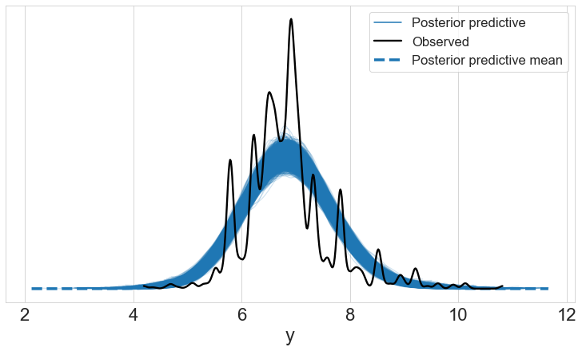

```python
with model:
    ppc = pm.sample_posterior_predictive(
        trace, random_seed=100
    )

az.plot_ppc(az.from_pymc3(posterior_predictive=ppc, model=model), figsize=(10,6));
```

It can be seen clearly that while the model does produce an estimate that is generally in line with the observed values, it misses a significant amount of variation in the response. This could be due to missing independent variables, such as the income of the individual arrested.

Another potential issue affecting the model could be improper data transformations. Since I am trying to predict the average bond amount for each individual (total bond amount charged/number of charges), there could be a significant amount of variance in the group of charges for an individual. This *should* be accounted for by grouping all of an individual's charges into a cluster of similar individuals, but more than likely there are cases where this adds noise into the model.

I still think that a Bayesian multivariate model could work for this data if we had more observations for certain subgroups in the data, better data labelling for the charges, and more data points to feed into the model. However, in this current state, it's not a very accurate model as it misses much of the variation between bond amounts charged.

## Bayesian Poisson Linear Regression for Daily Busted Counts

### Model Description and Estimation

Below I will fit a Poisson linear regression model with the following form:

$arrestcountperday = \beta_{intercept} + \beta_{dayofweek}*dayofweek + \beta_{month}*month + \beta_{year}*year$

This choice of variables is to see whether there is any predictive or explanatory power in the seasonality of the time series, at several different levels. This model should indicate what time periods have a significant impact on the number of arrests per day.

```python
# adding variables for the poisson regression

# add day of week as a variable
time_series['dayofweek'] = time_series.index.day_name().astype('category')

# add month as a variable
time_series['month'] = time_series.index.month.astype('category')

# add year as a variable
time_series['year'] = time_series.index.year.astype('category')

# creating the poisson regression model
with pm.Model() as model_poisson:
    # specify glm and pass in data. The resulting linear model, its likelihood and
    # and all its parameters are automatically added to our model.
    lm_poisson = pm.glm.GLM.from_formula("arrest_count ~ dayofweek + month + year",
                                 data = time_series,
                                family = pm.families.Poisson())
    trace_poisson = pm.sample(3000, tune = 2000, cores = 2)
```

```
Auto-assigning NUTS sampler...
Initializing NUTS using jitter+adapt_diag...
Multiprocess sampling (2 chains in 2 jobs)
NUTS: [mu, year[T.2021], year[T.2020], year[T.2019], month[T.12], month[T.11], month[T.10], month[T.9], month[T.8], month[T.7], month[T.6], month[T.5], month[T.4], month[T.3], month[T.2], dayofweek[T.Wednesday], dayofweek[T.Tuesday], dayofweek[T.Thursday], dayofweek[T.Sunday], dayofweek[T.Saturday],…
```

100.00% [10000/10000 00:56<00:00 Sampling 2 chains, 0 divergences]

```
Sampling 2 chains for 2_000 tune and 3_000 draw iterations (4_000 + 6_000 draws total) took 65 seconds.
```

### Model Summary

Now, let's display a table of the coefficient values. This will be a similar table to the initial linear model, with a 'Significant' column indicating whether or not the coefficient is significant at the 95% confidence level.

```python
poisson_summary = az.summary(trace_poisson, hdi_prob = .95, kind = 'stats' ).round(4)
poisson_summary['Significant'] = np.where((poisson_summary['hdi_2.5%'] < 0) & (poisson_summary['hdi_97.5%'] > 0), False, True)
poisson_summary
```

|  | mean | sd | hdi_2.5% | hdi_97.5% | Significant |
| --- | --- | --- | --- | --- | --- |
| Intercept | 1.451 | 0.100 | 1.265 | 1.656 | True |
| dayofweek[T.Monday] | -0.170 | 0.061 | -0.290 | -0.051 | True |
| dayofweek[T.Saturday] | -0.355 | 0.066 | -0.486 | -0.228 | True |
| dayofweek[T.Sunday] | -0.467 | 0.067 | -0.606 | -0.344 | True |
| dayofweek[T.Thursday] | -0.251 | 0.062 | -0.370 | -0.127 | True |
| dayofweek[T.Tuesday] | -0.074 | 0.059 | -0.186 | 0.045 | False |
| dayofweek[T.Wednesday] | -0.080 | 0.058 | -0.192 | 0.033 | False |
| month[T.2] | 0.006 | 0.079 | -0.146 | 0.158 | False |
| month[T.3] | 0.002 | 0.078 | -0.157 | 0.146 | False |
| month[T.4] | -0.088 | 0.084 | -0.248 | 0.076 | False |
| month[T.5] | 0.035 | 0.090 | -0.133 | 0.219 | False |
| month[T.6] | 0.026 | 0.087 | -0.145 | 0.193 | False |
| month[T.7] | 0.085 | 0.085 | -0.085 | 0.246 | False |
| month[T.8] | 0.087 | 0.087 | -0.094 | 0.247 | False |
| month[T.9] | 0.066 | 0.087 | -0.094 | 0.249 | False |
| month[T.10] | 0.152 | 0.082 | -0.008 | 0.315 | False |
| month[T.11] | 0.113 | 0.083 | -0.041 | 0.284 | False |
| month[T.12] | -0.071 | 0.085 | -0.233 | 0.097 | False |
| year[T.2019] | 0.161 | 0.072 | 0.020 | 0.301 | True |
| year[T.2020] | -0.038 | 0.074 | -0.177 | 0.111 | False |
| year[T.2021] | -0.040 | 0.096 | -0.226 | 0.147 | False |
| mu | 63.743 | 899.110 | 0.002 | 131.148 | True |

### Model Interpretation and Evaluation

It can be seen that the most significant variables are those for certain days of the week and the year 2019. The days of the week that are significant are Saturday, Sunday, Monday, and Thursday. The coefficients for these variables are all significantly negative (compared to the base case of Friday) at the 95% confidence level, indicating that arrests are lower for most days of the week compared to Friday. The year 2019 is also statistically significant at the 95% confidence level and is statistically positive compared to the base case of the year 2018. The fact that 2019 had a higher number of arrests than 2018 can be further evidenced by the monthly graph of the time series plotted in a section above.

It is interesting to see that after accounting for the daily and yearly seasonality, monthly seasonality shows no statistically significant effects across any of the months. This makes some sense, given that there doesn't appear to be any seasonality within the years in our data set, but is still somewhat surprising.

A caveat for this model's interpretation and estimation is that the dataset is very limited. We only have data back to October 2018 in this data set, and further complicating matters is that the COVID-19 pandemic did appear to have a significant effect on the number of arrests early in the pandemic (see March/April/May 2020 in the monthly time series chart). This alone could affect the estimation of the coefficients and therefore their interpretation.

Let's look and see if the model predicts the daily arrest counts in a distribution similar to that of the original data.

100.00% [6000/6000 00:05<00:00]

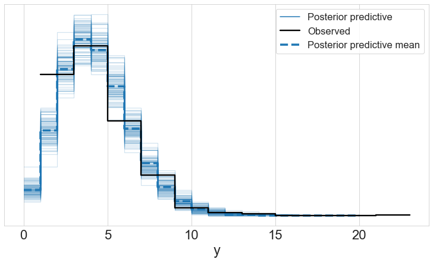

```python
with model_poisson:
    ppc_poisson = pm.sample_posterior_predictive(
        trace_poisson, random_seed=100
    )

az.plot_ppc(az.from_pymc3(posterior_predictive=ppc_poisson, model=model_poisson), figsize=(10,6), num_pp_samples = 100);
```

## Conclusions

I used Bayesian methods available in the pymc3 python library to fit linear models to a unique dataset of arrests.

In predicting bond amounts for an individual using linear regression, I found that while the shape of the data can be approximately with a linear model, much of the variation in the response variable is unexplained. I would be interested in exploring this topic further, possibly using Bayesian methods, other machine learning models, or just improving the dataset itself.

In explaining the seasonality of the time series of arrest counts per day, I found that a Bayesian fitted linear regression model can approximate the distribution of the data fairly well. The model also provides an explanation of which days of the week are more likely to see a higher number of arrests (via the coefficient values).

In using the pymc3 library, I enjoyed how easy it was to actually fit the model by using the simplified glm(), where you can input the model form in an "R-type" syntax. However, the time it takes to fit the model is very long compared to how long it takes to fit the same model in R using classical statistical techniques. Also, generating predictions using the models in pymc3 is (unless you have a simple model with a few parameters) seemingly not feasible. If I were fitting these models in practice, I would probably stick with R. However, if I needed to add informative priors on some of the parameters, and the model was simple enough in form, I would consider pymc3.

```python
#%load_ext watermark
%watermark -n -u -v -iv -w
```

```
Last updated: Sun Apr 25 2021

Python implementation: CPython
Python version       : 3.7.4
IPython version      : 7.8.0

scipy     : 1.3.1
arviz     : 0.11.2
numpy     : 1.17.2
seaborn   : 0.11.1
pandas    : 0.25.1
pymc3     : 3.11.1
matplotlib: 3.1.1
sys       : 3.7.4 (default, Aug 13 2019, 15:17:50)
[Clang 4.0.1 (tags/RELEASE_401/final)]

Watermark: 2.2.0
```